# project_Hyperboria

Rémy Cerda and Valentin Lorentz

29 novembre 2016

# Introduction

This project is about analysing latency and reachability on a mesh network, sometimes using a partial knowledge of its topology. We collected data on the Hyperboria network, which is a mesh network deployed both at local (over Ethernet) and global (over UDP) levels. Hyperboria has the advantage of making its list of nodes easily discoverable (it uses source routing), so we can get a list of most of the nodes of the network easily.

The database of pings it created by running 3 pings to each node, every 10 minutes, and storing the latency. The system running the script is hydrogen.hype.progval.net (fcd6:9c33:dd06:3320:8dbe:ab19:c87:f6e3).

# Producing data

On a computer connected to Hyperboria (and with `fc00::/8` routed to it), create the file “scan_data.csv” with this content:

```
timestamp,round_start_timestamp,node,seq,nb_bytes,ttl,latency
```

Then, run:

- `python3 ping_scan.py` wait for the results, press Ctrl-C. This will produce `scan_data.csv`.
- `gzip scan_data.csv` (the result is in this git repo)
- `cat scan_data.csv.gz | gunzip | sed "s/ ms//" | gzip > scan_data_fixed.csv.gz`

And:

- `wget https://www.fc00.org/static/graph.json` (the result is in this git repo)
- `python3 compute_distances.py`. This will produce `node_distances.csv`.

# Load data

## Data structure

Each line is a ping sent to an Hyperboria node, using Debian’s `ping`.

Columns are:

- timestamp: timestamp the ping was sent, as reported by ping.
- round_start_timestamp: timestamp the `ping` tool was invoked at.
- node: IPv6 address of the pinged node.
- seq: sequence number, as reported by ping. There is a bug with my script: for nodes that can be pinged, the seq is from 2 to 4, and for nodes which could not be reach it is from 0 to 2. The former should be fixed before analysing data.
- nb_bytes: number of bytes of the ICMP PING, as reported by ping
- ttl: ICMP TTL, as reported by ping
- latency: latency reported by ping.

```r
pings = read.csv("scan_data_fixed.csv.gz")
head(pings)
```

```
##    timestamp round_start_timestamp                                    node
## 1 1480525318            1480525317 fc92:bb4b:bff6:9102:693d:15b1:6443:3776
## 2 1480525319            1480525317 fc92:bb4b:bff6:9102:693d:15b1:6443:3776
## 3 1480525320            1480525317 fc92:bb4b:bff6:9102:693d:15b1:6443:3776
## 4         NA            1480525320 fc7c:0f6a:0118:5ff7:feed:46c5:9b4b:4e52
## 5         NA            1480525320 fc7c:0f6a:0118:5ff7:feed:46c5:9b4b:4e52
## 6         NA            1480525320 fc7c:0f6a:0118:5ff7:feed:46c5:9b4b:4e52
##   seq nb_bytes ttl latency
## 1   2       64  42   527.0
## 2   3       64  42   138.0
## 3   4       64  42    38.8
## 4   0       NA  NA      NA
## 5   1       NA  NA      NA
## 6   2       NA  NA      NA
```

```r
summary(pings)
```

```
##    timestamp         round_start_timestamp
##  Min.   :1.481e+09   Min.   :1.481e+09
##  1st Qu.:1.481e+09   1st Qu.:1.481e+09
##  Median :1.481e+09   Median :1.481e+09
##  Mean   :1.481e+09   Mean   :1.481e+09
##  3rd Qu.:1.481e+09   3rd Qu.:1.481e+09
##  Max.   :1.481e+09   Max.   :1.481e+09
##  NA's   :1287042
##                                       node              seq
##  fc00:0000:28a7:1600:168d:4349:4d28:ba73:    279   Min.   :0.000
##  fc00:10c1:9cec:1f1d:9513:c25b:a674:177a:    279   1st Qu.:0.000
##  fc00:241b:1dda:a401:7e5d:4b9b:e244:3868:    279   Median :1.000
##  fc00:439d:d7d9:a995:f35f:c44a:886d:6195:    279   Mean   :1.154
##  fc00:5555:b994:a83e:ea79:eabc:61a5:8af8:    279   3rd Qu.:2.000
##  fc00:ff0c:b73e:fbf8:f2f3:7b0d:acda:d5d2:    279   Max.   :4.000
##  (Other)                                :1392546
##     nb_bytes            ttl             latency
##  Min.   :64        Min.   :42.0      Min.   :    0.0
##  1st Qu.:64        1st Qu.:42.0      1st Qu.:  101.0
##  Median :64        Median :42.0      Median :  208.0
##  Mean   :64        Mean   :42.1      Mean   :  301.1
##  3rd Qu.:64        3rd Qu.:42.0      3rd Qu.:  378.0
##  Max.   :64        Max.   :64.0      Max.   :11459.0
##  NA's   :1287042   NA's   :1287042   NA's   :1287042
```

## Fixes

Compensate offset bug of the ping collection script.

```r
lines_with_seq_offset = !is.na(pings$latency)
pings$seq[lines_with_seq_offset] = pings$seq[lines_with_seq_offset]-2
summary(pings$seq)
```

```
##    Min. 1st Qu.  Median    Mean 3rd Qu.    Max.
##       0       0       1       1       2       2
```

## Distances database

The distance database is computed from the graph hosted at fc00.org. This graph is obtained from various probes on the network submitting their view of the network to fc00.org, which aggregates results.

Load the database:

```r
distances = read.csv("node_distances.csv")
```

Add distance column to the ping data:

```r
data = merge(pings, distances, by="node", all.x=TRUE)
head(data)
```

```
##                                      node timestamp round_start_timestamp
## 1 fc00:0000:0d7f:200e:0e96:71f8:03ab:aead        NA            1480525819
## 2 fc00:0000:0d7f:200e:0e96:71f8:03ab:aead        NA            1480525819
## 3 fc00:0000:0d7f:200e:0e96:71f8:03ab:aead        NA            1480525819
## 4 fc00:0000:0d7f:200e:0e96:71f8:03ab:aead        NA            1480526428
## 5 fc00:0000:0d7f:200e:0e96:71f8:03ab:aead        NA            1480526428
## 6 fc00:0000:0d7f:200e:0e96:71f8:03ab:aead        NA            1480526428
##   seq nb_bytes ttl latency distance
## 1   0       NA  NA      NA       NA
## 2   1       NA  NA      NA       NA
## 3   2       NA  NA      NA       NA
## 4   0       NA  NA      NA       NA
## 5   1       NA  NA      NA       NA
## 6   2       NA  NA      NA       NA
```

```r
summary(data)
```

```
##                                       node           timestamp
##  fc00:0000:28a7:1600:168d:4349:4d28:ba73:    279   Min.   :1.481e+09
##  fc00:10c1:9cec:1f1d:9513:c25b:a674:177a:    279   1st Qu.:1.481e+09
##  fc00:241b:1dda:a401:7e5d:4b9b:e244:3868:    279   Median :1.481e+09
##  fc00:439d:d7d9:a995:f35f:c44a:886d:6195:    279   Mean   :1.481e+09
##  fc00:5555:b994:a83e:ea79:eabc:61a5:8af8:    279   3rd Qu.:1.481e+09
##  fc00:ff0c:b73e:fbf8:f2f3:7b0d:acda:d5d2:    279   Max.   :1.481e+09
##  (Other)                                :1392546   NA's   :1287042
##  round_start_timestamp      seq       nb_bytes            ttl
##  Min.   :1.481e+09     Min.   :0   Min.   :64        Min.   :42.0
##  1st Qu.:1.481e+09     1st Qu.:0   1st Qu.:64        1st Qu.:42.0
##  Median :1.481e+09     Median :1   Median :64        Median :42.0
##  Mean   :1.481e+09     Mean   :1   Mean   :64        Mean   :42.1
##  3rd Qu.:1.481e+09     3rd Qu.:2   3rd Qu.:64        3rd Qu.:42.0
##  Max.   :1.481e+09     Max.   :2   Max.   :64        Max.   :64.0
##                                    NA's   :1287042   NA's   :1287042
##     latency           distance
##  Min.   :    0.0   Min.   :0
##  1st Qu.:  101.0   1st Qu.:2
##  Median :  208.0   Median :3
##  Mean   :  301.1   Mean   :3
##  3rd Qu.:  378.0   3rd Qu.:4
##  Max.   :11459.0   Max.   :6
##  NA's   :1287042   NA's   :1223067
```

# Analysis

## Latency distribution

First, let us have a look to the repartition of latency:

```r
summary(data$latency)
```

```
##    Min. 1st Qu.  Median    Mean 3rd Qu.    Max.    NA's
##     0.0   101.0   208.0   301.1   378.0 11460.0 1287042
```

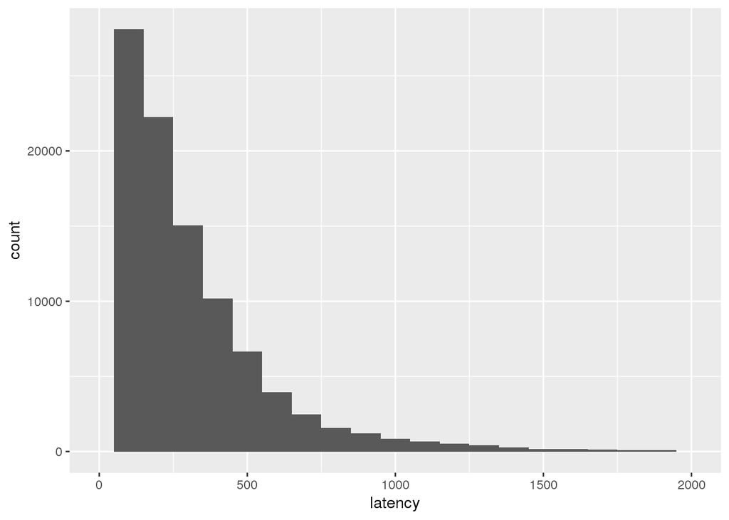

```r
ggplot(data=data, aes(x=latency)) + xlim(0, 2000) + geom_histogram(binwidth=100);
```

## Latency and distance

Let us draw histograms of latency for each distance:

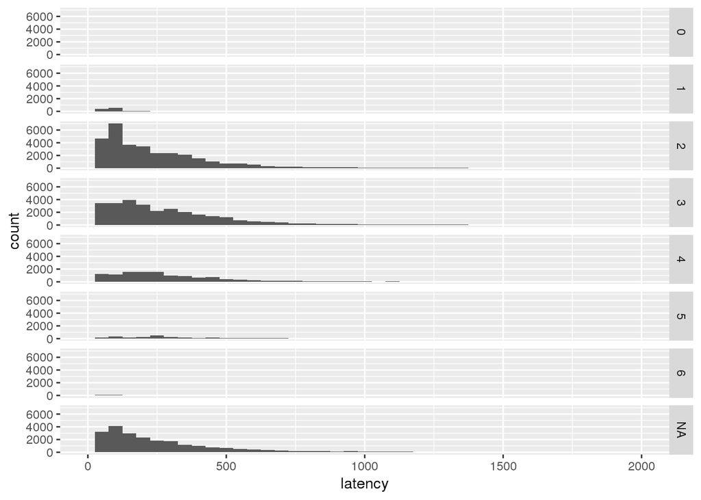

```r
ggplot(data=data, aes(x=latency)) + xlim(0, 2000) + geom_histogram(binwidth=50) + facet_grid(distance ~ .);
```

The graph is not really readable. Further analysis can be led using following boxplots:

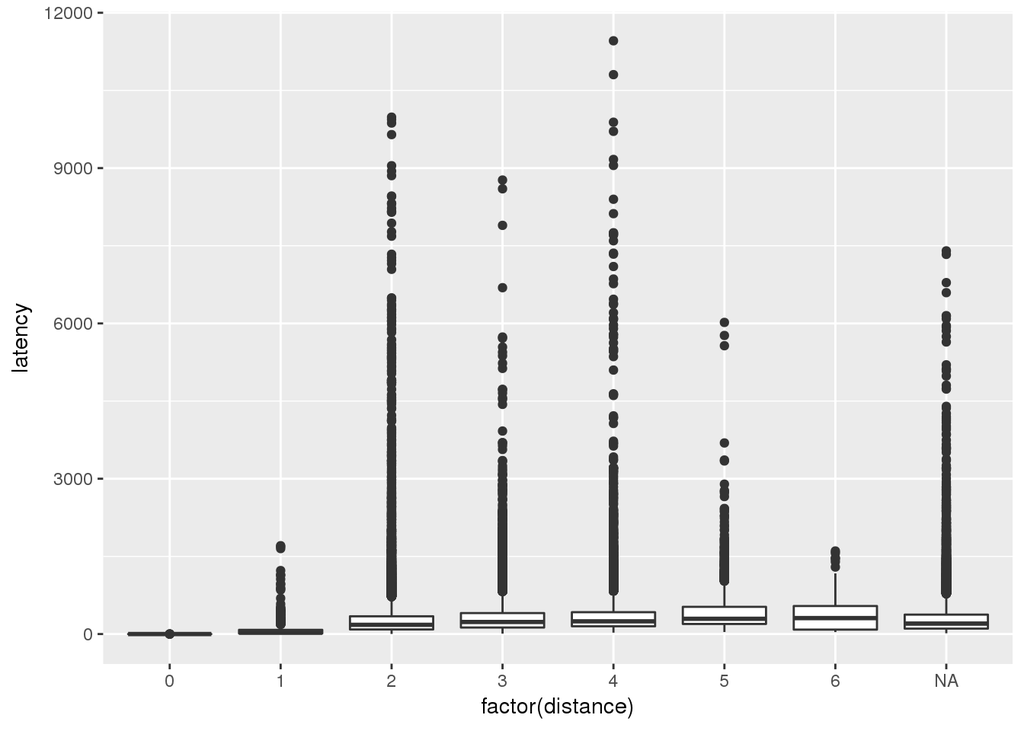

```r
ggplot(data=data, aes(x=factor(distance), y=latency)) + geom_boxplot();
```

And for readability, a log-scaled version:

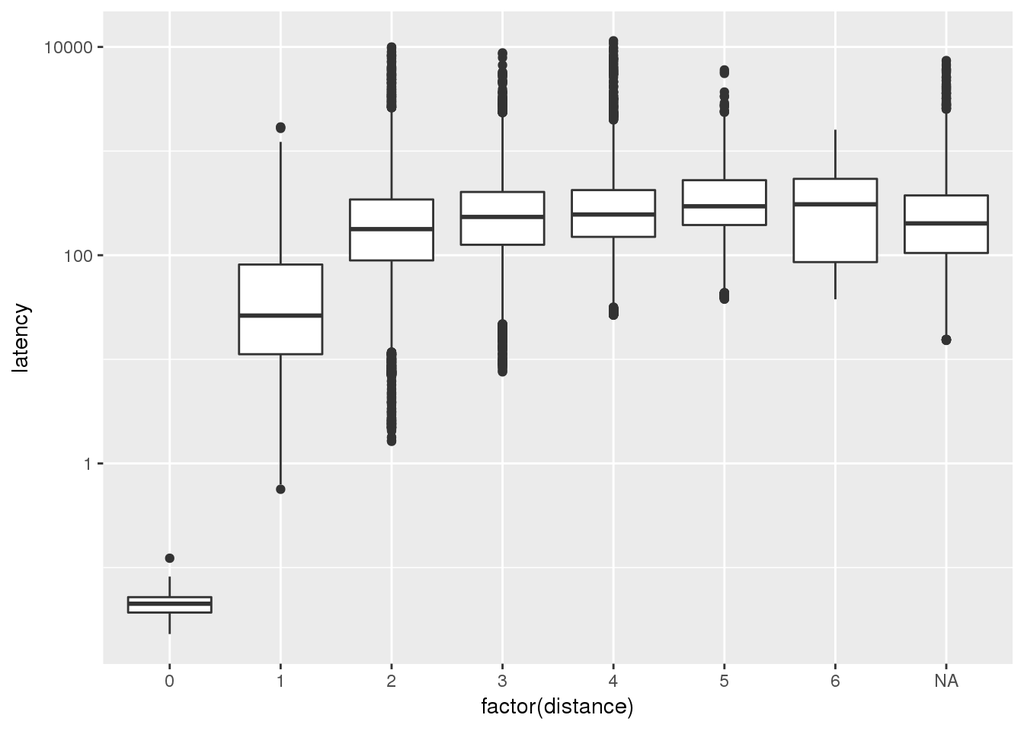

```r
ggplot(data=data, aes(x=factor(distance), y=latency)) + geom_boxplot() + scale_y_log10();
```

## Lag graph of latency

First, compute the difference of latency for each node, between sequences of 3 pings:

```r
aggregated_data = data %>% group_by(round_start_timestamp, node) %>% summarize(latency=mean(latency), distance=min(distance)) %>% filter(!is.na(latency)) %>% as.data.frame();
summary(aggregated_data$latency)
```

```
##      Min.   1st Qu.    Median      Mean   3rd Qu.      Max.
##     0.035   104.000   206.300   289.100   377.000 10720.000
```

```r
head(aggregated_data)
```

```
##   round_start_timestamp                                    node   latency
## 1            1480525317 fc92:bb4b:bff6:9102:693d:15b1:6443:3776  234.6000
## 2            1480525317 fc10:3143:0e44:5455:7ba9:a87d:aca0:77e3  952.3333
## 3            1480525317 fc05:77e4:1a0a:fe9b:63a3:f10b:6485:9073  219.3333
## 4            1480525317 fc18:8b6b:5c9f:8df0:9ec0:4386:2923:824d  157.0000
## 5            1480525317 fcf2:247d:9424:add5:4f56:ecc6:5f41:ac8e 1197.6667
## 6            1480525317 fc29:77dc:c12e:de78:b271:a12f:1c57:d798  545.0000
##   distance
## 1        2
## 2        3
## 3        3
## 4        3
## 5        5
## 6        2
```

```r
df_lag = aggregated_data %>% group_by(node) %>% mutate(old_latency=dplyr::lag(latency)) %>% mutate(latency_change=latency - old_latency) %>% mutate(relative_latency_change=latency_change/(old_latency+latency)) %>% as.data.frame()
head(df_lag)
```

```
##   round_start_timestamp                                    node   latency
## 1            1480525317 fc92:bb4b:bff6:9102:693d:15b1:6443:3776  234.6000
## 2            1480525317 fc10:3143:0e44:5455:7ba9:a87d:aca0:77e3  952.3333
## 3            1480525317 fc05:77e4:1a0a:fe9b:63a3:f10b:6485:9073  219.3333
## 4            1480525317 fc18:8b6b:5c9f:8df0:9ec0:4386:2923:824d  157.0000
## 5            1480525317 fcf2:247d:9424:add5:4f56:ecc6:5f41:ac8e 1197.6667
## 6            1480525317 fc29:77dc:c12e:de78:b271:a12f:1c57:d798  545.0000
##   distance old_latency latency_change relative_latency_change
## 1        2          NA             NA                      NA
## 2        3          NA             NA                      NA
## 3        3          NA             NA                      NA
## 4        3          NA             NA                      NA
## 5        5          NA             NA                      NA
## 6        2          NA             NA                      NA
```

```r
#ggplot(data=df_lag, aes(x=old_latency, y=latency)) + xlim(0, 2500) + ylim(0, 2500) + geom_point()
```

We can observe the distribution of latency changes:

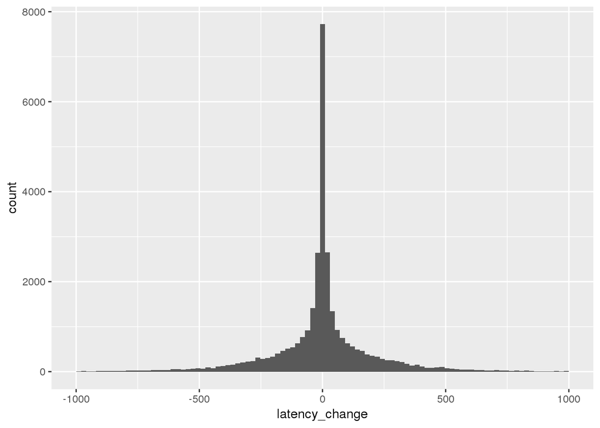

```r
ggplot(data=df_lag, aes(x=latency_change)) + xlim(-1000, 1000) + geom_histogram(bins=100)
```

```r
summary(df_lag$latency_change);
```

```
##       Min.    1st Qu.     Median       Mean    3rd Qu.       Max.
## -10670.000    -53.000      0.000     -0.058     51.670  10670.000
##       NA's
##        881
```

Scaled to the latency of each node:

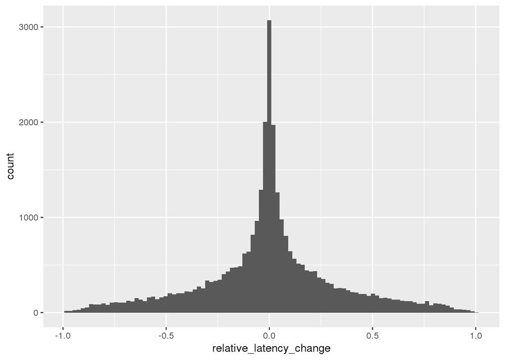

```r
ggplot(data=df_lag, aes(x=relative_latency_change)) + geom_histogram(bins=100)
```

```r
#ggplot(data=df_lag, aes(x=latency, y=relative_latency_change)) + geom_point()
summary(df_lag$relative_latency_change)
```

```
##    Min. 1st Qu.  Median    Mean 3rd Qu.    Max.    NA's
## -0.9931 -0.1359  0.0000 -0.0006  0.1375  0.9962     881
```

Finally, we can split this distribution over the different distances, which all seem to have a similar distribution:

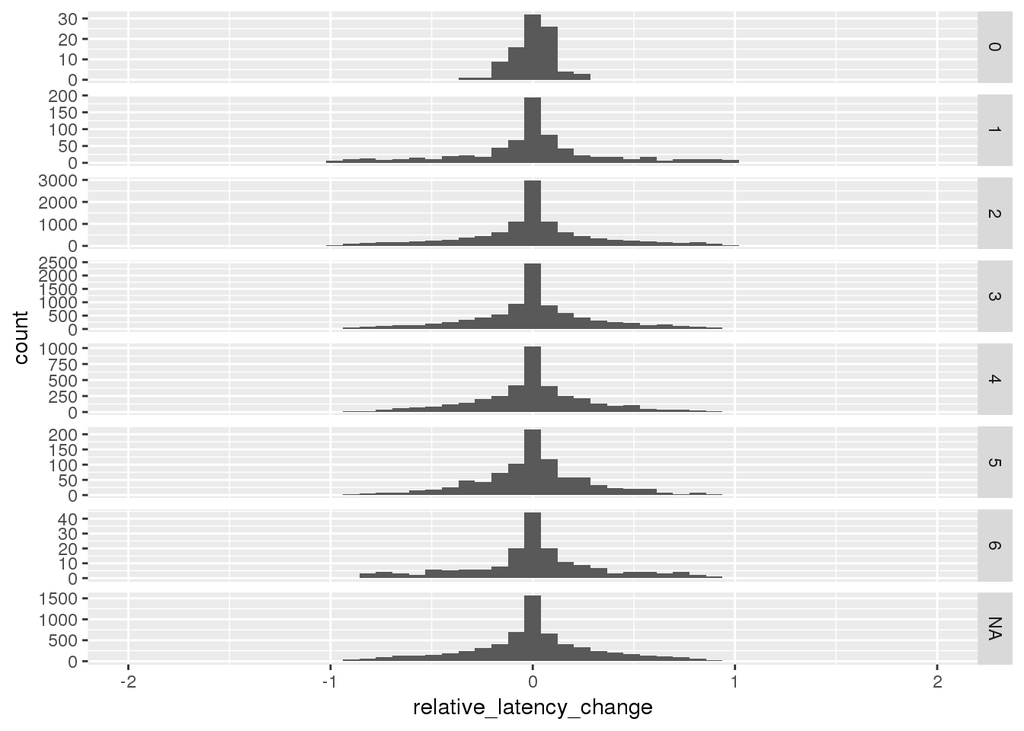

```r
ggplot(data=df_lag, aes(x=relative_latency_change)) + xlim(-2,2) + geom_histogram(bins=50) + facet_grid(distance ~ ., scale="free_y");
```

## Distribution of number of replies to ping from a node

Here, we are not interested in the latency, but whether or not a node replies.

First, compute the number of rounds in which each node responded (to the third ping), discarding nodes which never replies:

```r
df_counts = data %>% filter(seq == 2) %>% filter(!is.na(latency)) %>% group_by(node) %>% summarize(nb_replies=n(), distance=mean(distance)) %>% as.data.frame();
summary(df_counts)
```

```
##                                       node       nb_replies
##  fc00:0000:28a7:1600:168d:4349:4d28:ba73:  1   Min.   : 1.00
##  fc00:241b:1dda:a401:7e5d:4b9b:e244:3868:  1   1st Qu.:15.00
##  fc00:439d:d7d9:a995:f35f:c44a:886d:6195:  1   Median :34.00
##  fc00:501f:c1d2:4346:0071:91d8:00ae:7cfd:  1   Mean   :40.52
##  fc00:5555:b994:a83e:ea79:eabc:61a5:8af8:  1   3rd Qu.:67.00
##  fc00:89f7:d7f7:d731:f09c:5f03:c462:67cc:  1   Max.   :93.00
##  (Other)                                :879
##     distance
##  Min.   :0.00
##  1st Qu.:2.00
##  Median :3.00
##  Mean   :2.92
##  3rd Qu.:3.00
##  Max.   :6.00
##  NA's   :374
```

```r
head(df_counts)
```

```
##                                      node nb_replies distance
## 1 fc00:0000:28a7:1600:168d:4349:4d28:ba73         86        3
## 2 fc00:241b:1dda:a401:7e5d:4b9b:e244:3868         15        5
## 3 fc00:439d:d7d9:a995:f35f:c44a:886d:6195         74        2
## 4 fc00:501f:c1d2:4346:0071:91d8:00ae:7cfd         15       NA
## 5 fc00:5555:b994:a83e:ea79:eabc:61a5:8af8         14       NA
## 6 fc00:89f7:d7f7:d731:f09c:5f03:c462:67cc         33       NA
```

Although we cannot see any apparent pattern on global statistics…

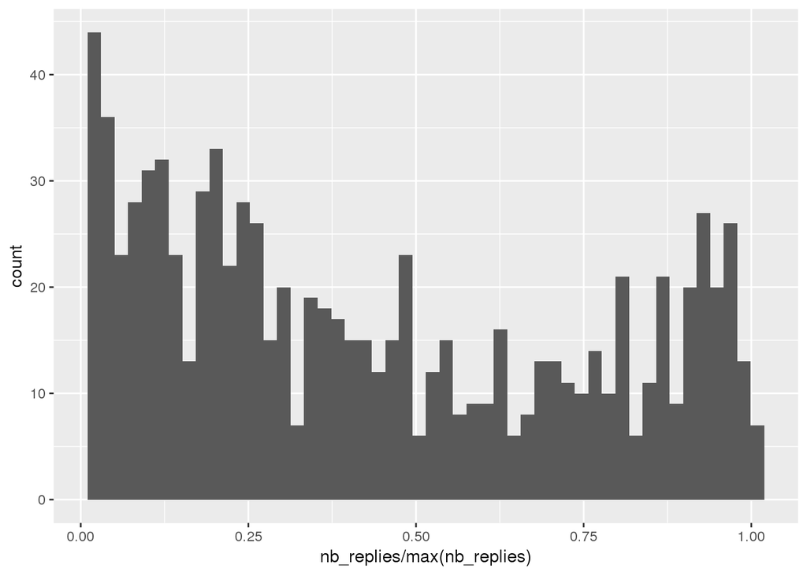

```r
ggplot(data=df_counts, aes(x=nb_replies/max(nb_replies))) + geom_histogram(bins=50);
```

… we can see a mostly-linear decrease of the ratio replies when the distance increases. Note that NA is for nodes which are not on the graph of fc00 – usually because none of the probes know where on the graph they are, which is either caused by them being far for the probe / hard to reach / not very reliable.

We can also note that nodes at distance 1 are highly reliable – a potential bias to this is that they are direct peers of the source node (Hydrogen), which I chose myself for their reliability. Nodes at distance >= are more evenly distributed, because Hydrogen’s peers are far more open on their peering policy.

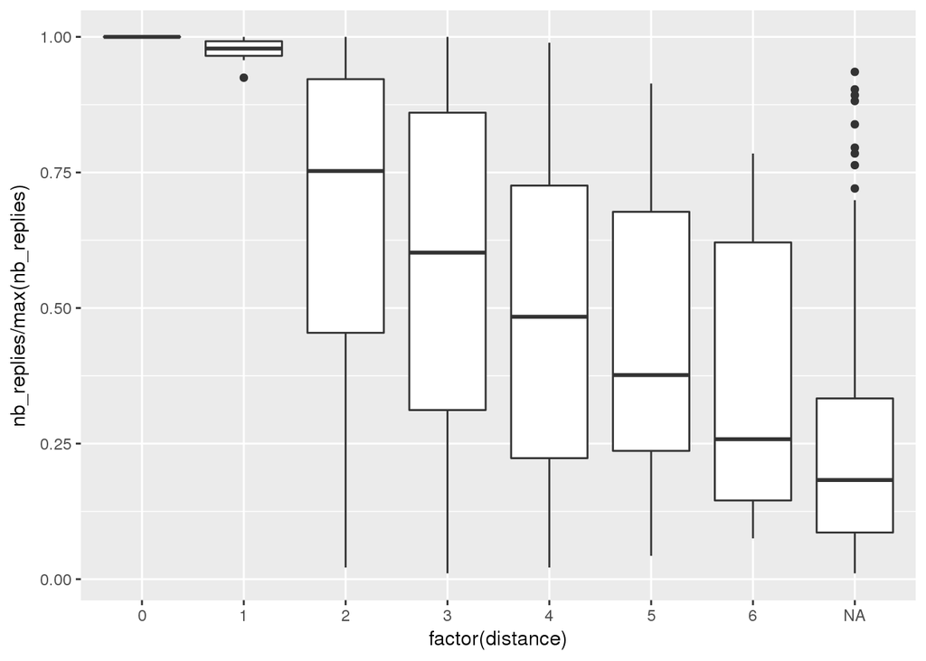

```r
ggplot(data=df_counts, aes(x=factor(distance), y=nb_replies/max(nb_replies))) + geom_boxplot();
```